# Lab3

2022-09-08

Music data set

```r
music <- read.csv('/Users/priya/Stat475/music-plusnew-sub.csv', row.names=1, stringsAsFactors=FALSE)
dim(music)
```

```
## [1] 62  7
```

```r
colnames(music)
```

```
## [1] "Artist" "Type"   "LVar"   "LAve"   "LMax"   "LFEner" "LFreq"
```

```r
head(music)
```

```
##               Artist Type     LVar      LAve  LMax   LFEner     LFreq
## Dancing Queen   Abba Rock 17600756 -90.00687 29921 105.9210  59.57379
## Knowing Me      Abba Rock  9543021 -75.76672 27626 102.8362  58.48031
## Take a Chance   Abba Rock  9049482 -98.06292 26372 102.3249 124.59397
## Mamma Mia       Abba Rock  7557437 -90.47106 28898 101.6165  48.76513
## Lay All You     Abba Rock  6282286 -88.95263 27940 100.3008  74.02039
## Super Trouper   Abba Rock  4665867 -69.02084 25531 100.2485  81.40140
```

```r
summary(music)
```

```
##     Artist              Type                LVar                LAve
##  Length:62          Length:62          Min.   :   293608   Min.   :-98.063
##  Class :character   Class :character   1st Qu.:  2844213   1st Qu.: -6.253
##  Mode  :character   Mode  :character   Median :  8210359   Median : -5.662
##                                        Mean   : 19951792   Mean   : -7.807
##                                        3rd Qu.: 24547475   3rd Qu.:  1.962
##                                        Max.   :129472199   Max.   :216.232
##       LMax           LFEner           LFreq
##  Min.   : 2985   Min.   : 83.88   Min.   : 41.41
##  1st Qu.:16200   1st Qu.:101.69   1st Qu.: 99.18
##  Median :24431   Median :104.35   Median :175.29
##  Mean   :22486   Mean   :104.03   Mean   :231.39
##  3rd Qu.:29919   3rd Qu.:108.15   3rd Qu.:315.12
##  Max.   :32766   Max.   :114.00   Max.   :877.77
```

```r
table(music$Type)
```

```
##
## Classical  New wave      Rock
##        24         3        30
```

```r
table(music$Artist)
```

```
##
##      Abba   Beatles Beethoven      Eels      Enya    Mozart   Vivaldi
##        10        10         8        10         3         6        10
```

body fat data set

```r
bodyfat <- read.csv('/Users/priya/Stat475/bodyfat.csv')
dim(bodyfat)
```

```
## [1] 252  14
```

```r
colnames(bodyfat)
```

```
##  [1] "Percent.Body.Fat" "Ageyrs"           "Weightlbs"        "Heightinches"
##  [5] "NeckCircm"        "ChestCircm"       "AbdomenCircm"     "HipCircm"
##  [9] "ThighCircm"       "KneeCircm"        "AnkleCircm"       "BicepsCircm"
## [13] "ForearmCircm"     "WristCircm"
```

```r
head(bodyfat)
```

```
##   Percent.Body.Fat Ageyrs Weightlbs Heightinches NeckCircm ChestCircm
## 1             12.3     23    154.25        67.75      36.2       93.1
## 2              6.1     22    173.25        72.25      38.5       93.6
## 3             25.3     22    154.00        66.25      34.0       95.8
## 4             10.4     26    184.75        72.25      37.4      101.8
## 5             28.7     24    184.25        71.25      34.4       97.3
## 6             20.9     24    210.25        74.75      39.0      104.5
##   AbdomenCircm HipCircm ThighCircm KneeCircm AnkleCircm BicepsCircm
## 1         85.2     94.5       59.0      37.3       21.9        32.0
## 2         83.0     98.7       58.7      37.3       23.4        30.5
## 3         87.9     99.2       59.6      38.9       24.0        28.8
## 4         86.4    101.2       60.1      37.3       22.8        32.4
## 5        100.0    101.9       63.2      42.2       24.0        32.2
## 6         94.4    107.8       66.0      42.0       25.6        35.7
##   ForearmCircm WristCircm
## 1         27.4       17.1
## 2         28.9       18.2
## 3         25.2       16.6
## 4         29.4       18.2
## 5         27.7       17.7
## 6         30.6       18.8
```

Pisa math means data set

```r
pisamath <-read.csv('/Users/priya/Stat475/pisamathmeans.csv')
dim(pisamath)
```

```
## [1] 10294     8
```

```r
summary(pisamath)
```

```
##     Gender               acc             acq             acs
##  Length:10294       Min.   :162.8   Min.   :115.1   Min.   :115.8
##  Class :character   1st Qu.:426.1   1st Qu.:412.2   1st Qu.:399.9
##  Mode  :character   Median :494.2   Median :483.6   Median :467.5
##                     Mean   :497.3   Mean   :483.0   Mean   :471.1
##                     3rd Qu.:566.1   3rd Qu.:552.5   3rd Qu.:537.8
##                     Max.   :827.2   Max.   :792.6   Max.   :809.7
##                     NA's   :4978    NA's   :4978    NA's   :4978
##       acu             ape             apf              api
##  Min.   :165.2   Min.   :153.7   Min.   : 93.87   Min.   : 97.76
##  1st Qu.:431.9   1st Qu.:420.8   1st Qu.:411.89   1st Qu.:428.03
##  Median :495.6   Median :486.4   Median :480.07   Median :497.05
##  Mean   :497.6   Mean   :487.5   Mean   :484.73   Mean   :498.71
##  3rd Qu.:559.9   3rd Qu.:551.8   3rd Qu.:553.87   3rd Qu.:566.00
##  Max.   :785.0   Max.   :778.7   Max.   :841.34   Max.   :837.44
##  NA's   :4978    NA's   :4978    NA's   :4978     NA's   :4978
```

Software

```r
library(ggplot2)
library(GGally)
```

Exercise 1 Music clips data

```r
table(music$Type)
```

```
##
## Classical  New wave      Rock
##        24         3        30
```

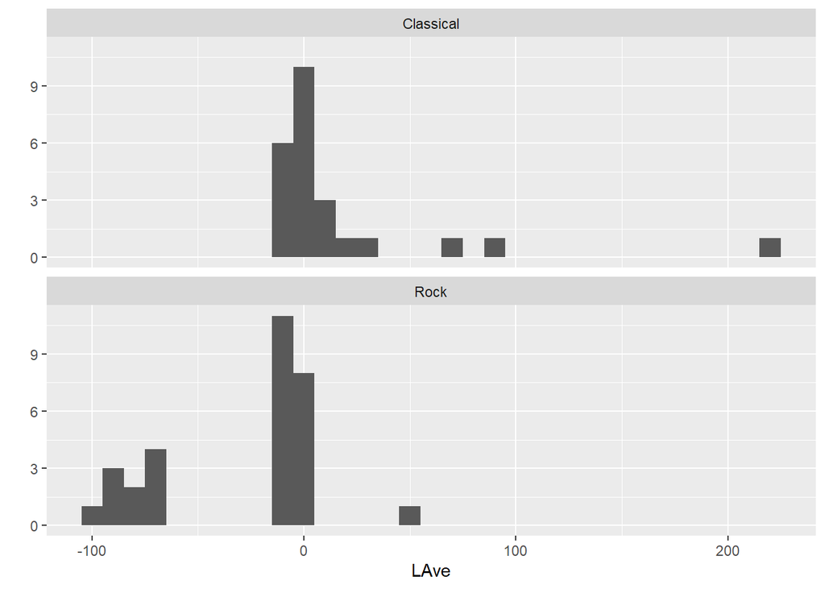

```r
music.sub <- subset(music, Type == "Rock" | Type == "Classical")
qplot(LAve, data=music.sub, geom="histogram", binwidth=10.0) + facet_wrap(~Type, ncol=1)
```

1. The classical histogram is skewed to the right and the Rock histogram is more spread out. Classical histogram has 3 outliers and the rock histogram has 1. Both of the histograms are not normal.

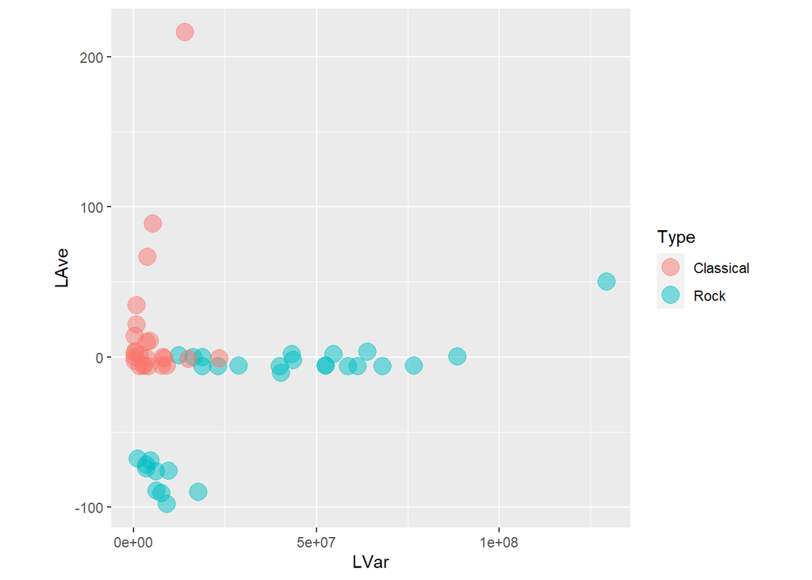

```r
qplot(LVar, LAve, data=music.sub, color=Type, size=I(5), alpha=I(0.5)) + theme(aspect.ratio=1)
```

B) Classical music is less spread out and the LVar values are between 0 and 5e+07, while Rock has more variation in the LVar values. However, when looking at LAve values, Classical music is more spread out while Rock stays around 0 and -100.

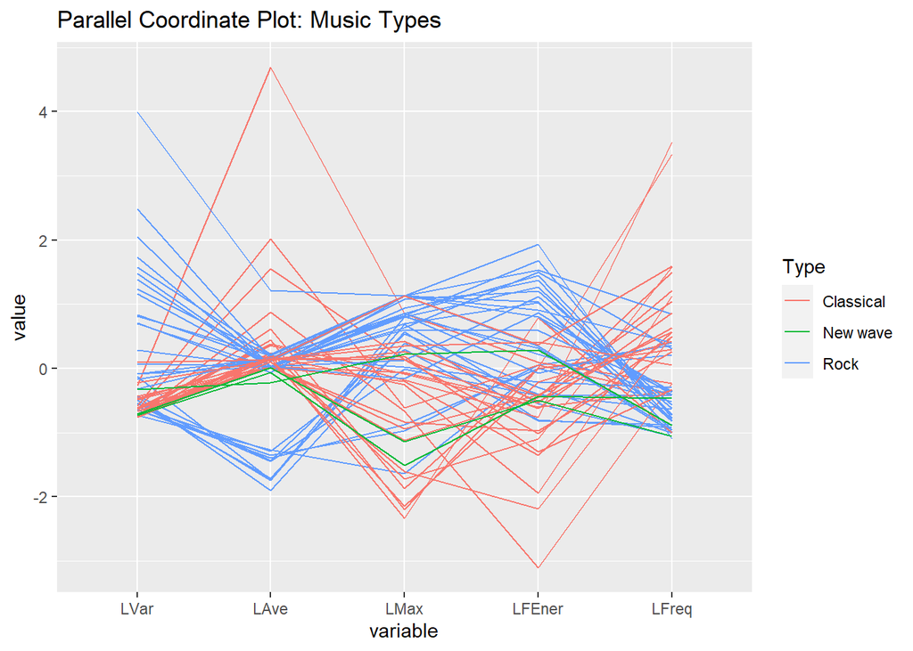

```r
music.sub2 <- subset(music, Type == "Rock" | Type == "Classical" | Type=="New wave")
ggparcoord(music.sub2, columns=3:7, groupColumn="Type",
             title="Parallel Coordinate Plot: Music Types")
```

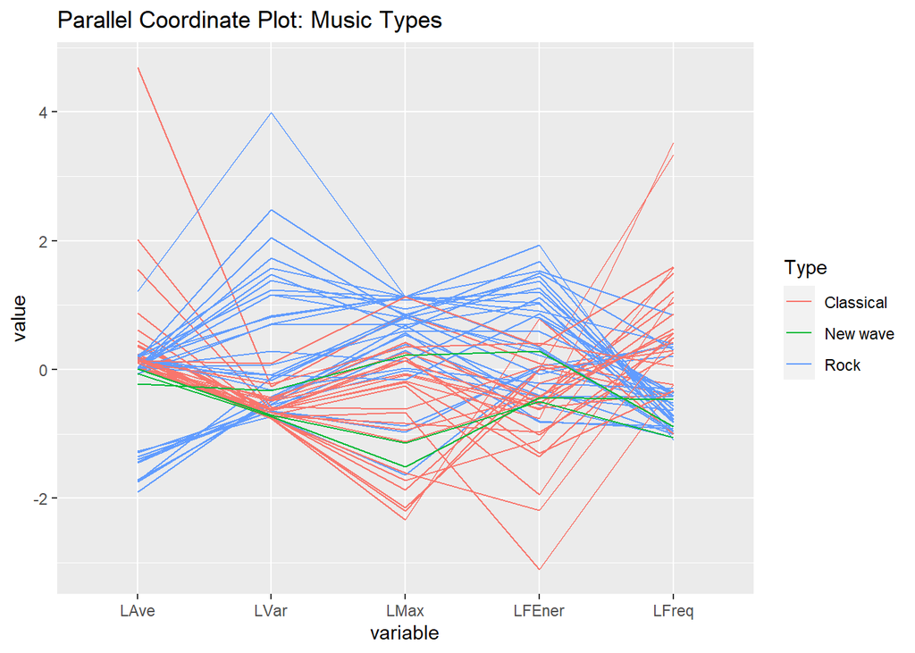

```r
ggparcoord(music.sub2, columns=c(4, 3, 5, 6, 7),
             groupColumn="Type",
             title="Parallel Coordinate Plot: Music Types")
```

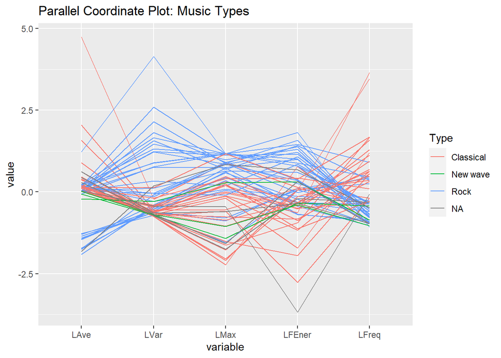

```r
ggparcoord(music, columns=c(4, 3, 5, 6, 7),
             groupColumn="Type", missing="exclude",
             title="Parallel Coordinate Plot: Music Types")
```

C) Rock has more LVar and LFEner values than the rest of the music types and has the lowest LAve. Classical music has higher LFreq values and LAve values and has the lowest LMax values. New wave has mostly similar values between the variables with the lowest being in LMax.

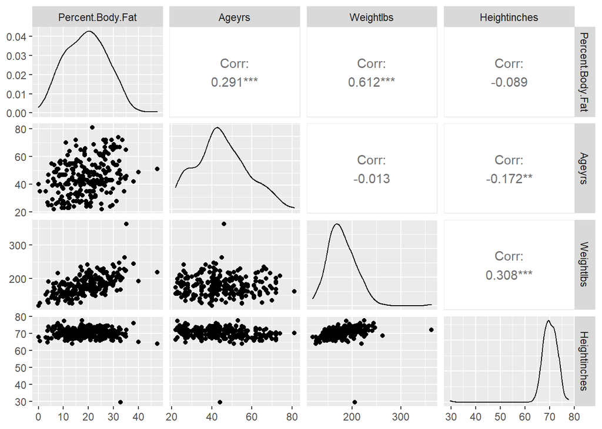

```r
ggpairs(bodyfat[,1:4])
```

1) The correlation between the variables are not linear but more uniform. The Height Variable has a uniform relationship with the other variables. Bodyfat and Age have a more positive relationship but it is not linear. Body fat and Wight has a moderate positive relationship with one outlier. Weight and Age do not have the best relationship since the correlation is close to 0. The same goes with Height and body fat.

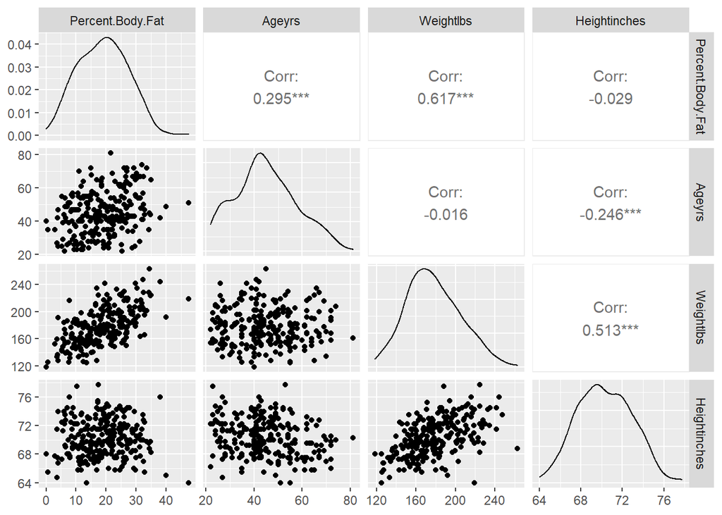

```r
bf.sub <- subset(bodyfat, Heightinches > 60 & Weightlbs < 300)
ggpairs(bf.sub[,1:4])
```

2. This plot removes the outliers for the person who is under 40 inches and and other person who weighs more than 300 pounds. This removes the outliers making the correlation between the variables stronger. Weight and Body fat has a strong positve linear relationship. Weight and Height have a moderate positive linear relationship. Height and Age have a weak negative relationship. Weight and Age has a very weak relationship almost to 0.

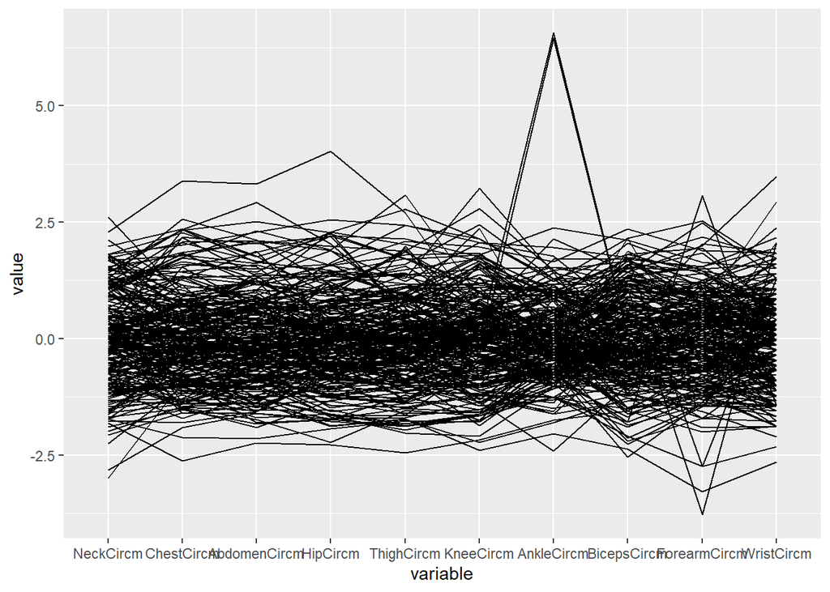

```r
ggparcoord(bf.sub, 5:14)
```

3. There is a very high value of AnkleCircm that is over 5.0. This is considered to be an outlier and can affect the data.

```r
summary(bf.sub$AnkleCircm)
```

```
##    Min. 1st Qu.  Median    Mean 3rd Qu.    Max.
##   19.10   22.00   22.80   23.07   24.00   33.90
```

```r
sort(bf.sub$AnkleCircm)
```

```
##   [1] 19.1 19.7 20.1 20.2 20.4 20.4 20.5 20.6 20.8 20.9 21.0 21.0 21.0 21.0 21.0
##  [16] 21.0 21.3 21.3 21.4 21.4 21.4 21.4 21.5 21.5 21.5 21.5 21.5 21.5 21.5 21.5
##  [31] 21.6 21.6 21.6 21.7 21.7 21.7 21.7 21.8 21.8 21.8 21.8 21.8 21.8 21.8 21.8
##  [46] 21.8 21.8 21.9 21.9 21.9 21.9 21.9 21.9 21.9 21.9 22.0 22.0 22.0 22.0 22.0
##  [61] 22.0 22.0 22.0 22.0 22.0 22.0 22.1 22.1 22.1 22.1 22.1 22.1 22.1 22.2 22.2
##  [76] 22.2 22.2 22.3 22.3 22.3 22.3 22.3 22.3 22.3 22.4 22.4 22.4 22.4 22.4 22.4
##  [91] 22.4 22.4 22.5 22.5 22.5 22.5 22.5 22.5 22.5 22.5 22.5 22.5 22.5 22.6 22.6
## [106] 22.6 22.6 22.6 22.6 22.6 22.6 22.6 22.6 22.6 22.7 22.7 22.7 22.7 22.7 22.7
## [121] 22.7 22.7 22.7 22.8 22.8 22.8 22.8 22.8 22.9 22.9 22.9 22.9 22.9 22.9 22.9
## [136] 23.0 23.0 23.0 23.0 23.0 23.0 23.1 23.1 23.1 23.1 23.1 23.2 23.2 23.2 23.2
## [151] 23.2 23.2 23.2 23.2 23.2 23.3 23.3 23.3 23.3 23.4 23.4 23.4 23.4 23.4 23.4
## [166] 23.4 23.4 23.5 23.5 23.5 23.5 23.6 23.6 23.6 23.6 23.7 23.7 23.7 23.8 23.8
## [181] 23.8 23.8 23.8 23.9 23.9 24.0 24.0 24.0 24.0 24.0 24.0 24.0 24.0 24.1 24.1
## [196] 24.1 24.1 24.1 24.1 24.2 24.4 24.4 24.5 24.5 24.5 24.5 24.6 24.6 24.6 24.6
## [211] 24.6 24.6 24.6 24.6 24.7 24.7 24.7 24.7 24.7 24.7 24.7 24.8 24.8 24.8 24.8
## [226] 24.8 24.9 25.0 25.0 25.0 25.0 25.1 25.2 25.2 25.2 25.2 25.4 25.4 25.5 25.5
## [241] 25.6 25.6 25.8 25.9 26.0 26.3 26.6 27.0 33.7 33.9
```

```r
bf.sub[bf.sub$AnkleCircm > 33,]
```

```
##    Percent.Body.Fat Ageyrs Weightlbs Heightinches NeckCircm ChestCircm
## 31             11.9     32       182        73.75      38.7      100.5
## 86             26.6     67       167        67.50      36.5       98.9
##    AbdomenCircm HipCircm ThighCircm KneeCircm AnkleCircm BicepsCircm
## 31         88.7     99.8       57.5      38.7       33.9        32.5
## 86         89.7     96.2       54.7      37.8       33.7        32.4
##    ForearmCircm WristCircm
## 31         27.7       18.4
## 86         27.7       18.2
```

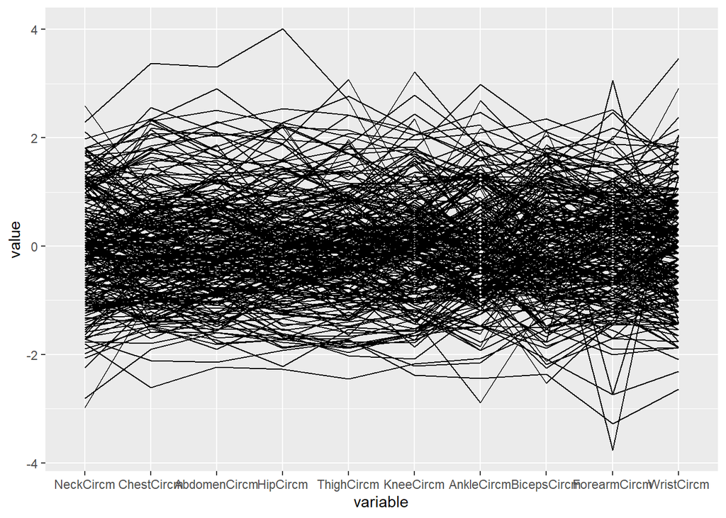

```r
bf.sub2 <- subset(bf.sub, AnkleCircm < 33)
ggparcoord(bf.sub2, 5:14)
```

4)By removing the oulier, the graph looks a lot more neater. There are high values in the Hip of 4, Abdomen of approximately 3 and ChestCircm of 3 and there is a low value of -3.5 for the forearmCircm. However, other than that, the values are between -3 and 3 and looks like a normal relationship.

```r
pisamath2 <- subset(pisamath, !is.na(acc))
summary(pisamath2)
```

```
##     Gender               acc             acq             acs
##  Length:5316        Min.   :162.8   Min.   :115.1   Min.   :115.8
##  Class :character   1st Qu.:426.1   1st Qu.:412.2   1st Qu.:399.9
##  Mode  :character   Median :494.2   Median :483.6   Median :467.5
##                     Mean   :497.3   Mean   :483.0   Mean   :471.1
##                     3rd Qu.:566.1   3rd Qu.:552.5   3rd Qu.:537.8
##                     Max.   :827.2   Max.   :792.6   Max.   :809.7
##       acu             ape             apf              api
##  Min.   :165.2   Min.   :153.7   Min.   : 93.87   Min.   : 97.76
##  1st Qu.:431.9   1st Qu.:420.8   1st Qu.:411.89   1st Qu.:428.03
##  Median :495.6   Median :486.4   Median :480.07   Median :497.05
##  Mean   :497.6   Mean   :487.5   Mean   :484.73   Mean   :498.71
##  3rd Qu.:559.9   3rd Qu.:551.8   3rd Qu.:553.87   3rd Qu.:566.00
##  Max.   :785.0   Max.   :778.7   Max.   :841.34   Max.   :837.44
```

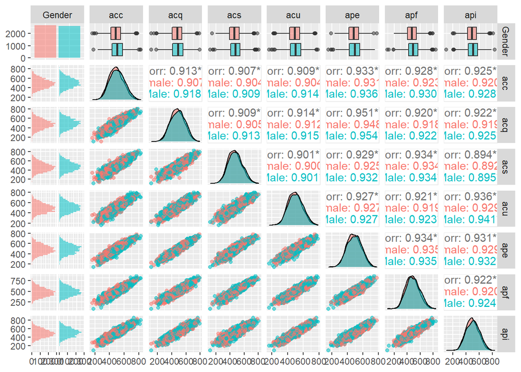

```r
ggpairs(pisamath2, mapping=aes(color=Gender, alpha=0.5))
```